# Project 2

Brandon Tsai

# Introduction

### Scientific Question

Are the 3 most upregulated genes in the coral Balanophyllia elegans in an acidic ocean condition specific to the biological processes that corals undergo (e.g. calcification and skeletal matrix formation), or are they associated with broad biological processes that are shared among other organisms?

### Background

The coral Balanophyllia elegans, commonly called the orange cup coral, is a round coral with tentacles that looks similar to a sea anemone. It primarily lives in rocky intertidal shores along the west coast of North America, ranging from Alaska to Baja California. As is typical for corals, this species has a skeletal matrix made out of calcium carbonate. because of its calcium carbonate skeleton, this coral is susceptible to the effects of ocean acidification, as a lower pH will reduce the ability of the coral to build its skeleton. Specifically, a lower pH in the ocean reduces the abundance of carbonate ions in the water, which the coral needs to produce calcium carbonate and form its skeleton. If the coral is unable to take in enough carbonate ions to undergo normal skeletal growth, then it will erode and essentially die. As ocean acidification is continuously worsening over time, skeleton-building corals like Balanophyllia elegans face a great threat if they are not able to adapt and become resilient against these environmental pressures. Thus, studying how this coral responds to acidifying conditions by altering the expression of genes, and ultimately producing certain proteins to confer greater resilience, is important to understanding the potential for this coral to withstand these stressful conditions. However, it is unclear whether the changes in expression in response to acidification occur in genes that are specific to the biological processes that corals undergo, such as calcification or skeletal matrix formation, or if the changes in expression mainly occur in genes that influence broad cellular or physiological processes that many other organisms undergo as well.

Sources:

https://www.centralcoastbiodiversity.org/orange-cup-coral-bull-balanophyllia-elegans.html

https://usa.oceana.org/effects-ocean-acidification-corals/

### Hypothesis

If the most highly expressed genes in the coral Balanophyllia elegans in acidic ocean conditions are associated with calcification or skeletal matrix formation which are specific to corals, then these corals would undergo specialized changes in response to ocean acidification rather than changing broad cellular or physiological processes that are shared among many other organisms.

### Analysis and data for the study

The first step of analysis is to perform differential gene expression analysis to examine how genes are differentially expressed in the coral between a low acidity and a high acidity condition. For this analysis, the read counts obtained from RNA Seq and the metadata were retrieved from https://github.com/JoannaGriffiths/Coral-population-responses-to-acidification. This dataset was used for the Griffiths et al. 2019 study “Differential responses to ocean acidification between populations of Balanophyllia elegans corals from high and low upwelling environments”. However, the dataset that I am using is simplified and only includes data from one population instead of two populations that were used in the original study. A heatmap and PCA will be used to visualize patterns of gene expression in both low and high acidity conditions. From the results of the differential expression analysis, the top 3 genes that are most upregulated in corals in a highly acidic condition will be selected for the next step of the analysis. A gene ontology (GO) analysis will be performed for each of these three genes to identify the products or functions associated with these genes. Afterward, a BLAST search on the genes obtained from NCBI (the code will be executed in R) will be performed to further investigate other homologous sequences and to infer whether these respective genes are present only in corals or in other organisms as well.

# Loading in packages

Here is the code to load in each of the packages,

```r
#load pheatmap package. The pheatmap package is used to generate a heatmap, which visualizes the results of the differential gene expression analysis by comparing correlations in gene expression among each sample
library(pheatmap)

#load RColorBrewer package. This package provides different color schemes when making certain graphs such as heatmaps. For this study, a heatmap will be made and RColorBrewer is able to specify the colors for this heatmap.
library(RColorBrewer)

#load tidyverse package. The tidyverse package includes several useful packages with many functions that are meant to make coding on R a lot more efficient and organized. Specifically, the tidyverse package allows me to use the %>% characters to turn my code into a pipeline
library(tidyverse)
#The code below is used to install packages from BioConductor but it is put inside comments because it takes a long time to install the packages when I knit the code. These are here in case you need to install them

#if (!require("BiocManager", quietly = TRUE))
    #install.packages("BiocManager")
#BiocManager::install("DESeq2")
#BiocManager::install("org.Hs.eg.db")
#BiocManager::install("GO.db")
#BiocManager::install("limma")

#load packages from BioConductor

#load DESeq2 package. The DESeq2 package is used to perform the differential gene expression analysis and involves functions such as DESeqDataSetFromMatrix and DESeq.
library(DESeq2)
#load org.Hs.eg.db, GO.db, and limma packages. These three packages are grouped together because they are involved in the gene ontology (GO) analysis. The org.Hs.eg.db and Go.db packages provide access to the online databases (specifically the GO database) that are required for the GO analysis so that I can access these databases directly from R. The limma package is required for the "goana" function which performs the GO analysis on R -- it allows me to input the genes that I want to perform the GO analysis on and outputs a table of the results
library(org.Hs.eg.db)
library(GO.db)
library(limma)
#load annotate package. The annotate package is required to perform the BLAST search on R. It is a useful package to perform gene annotations, which are a large component of the BLAST search.
library(annotate)
```

# Bioinformatics Analysis

## Bioinformatics Method 1: DESeq Analysis

DESeq analysis stands for differential expression analysis. It looks at the read counts of genes whose transcripts have been sequenced (such as through RNA Seq) and analyzes these counts to see which genes are expressed differently under different conditions. DESeq analysis also quantifies the magnitude by which a gene is differentially expressed and how statistically significant this change in expression is among different conditions. DESeq analysis requires data from the raw counts of the gene transcripts that were sequenced (in this case I will import the raw counts as a csv file) as well as the metadata which contains information about each of the sample groups and the conditions/treatments for each sample group that pertain to the raw counts.

```r
#read in the data of raw counts of the genes in the coral obtained from RNA Seq from https://github.com/JoannaGriffiths/Coral-population-responses-to-acidification. This is a global variable.
rawcounts <- read.csv("project_2_rawcounts.csv")
#view the first few rows of the raw counts
head(rawcounts)
```

|  | library | P1L1 | P2L1 | P1H1 | P2H1 | P3L1 | P3H1 | P1L2 | P2L2 | P1H2 | P2H2 | P3L2 | P3H2 |
| --- | --- | --- | --- | --- | --- | --- | --- | --- | --- | --- | --- | --- | --- |
| 1 | OG0000000: | 0.00 | 100.34 | 0.00 | 54.00 | 149.15 | 421.93 | 1.00 | 5964.46 | 0.00 | 62.97 | 4.00 | 9836.82 |
| 2 | OG0000001: | 666.02 | 806.14 | 1275.01 | 777.08 | 1205.26 | 1873.19 | 8980.75 | 8601.72 | 2789.43 | 8967.41 | 8384.28 | 8610.65 |
| 3 | OG0000002: | 4.00 | 28.65 | 25.77 | 17.54 | 99.39 | 214.15 | 19.26 | 4690.69 | 59.06 | 25.63 | 10.00 | 245.38 |
| 4 | OG0000003: | 2676.20 | 4415.33 | 3709.50 | 3902.06 | 4563.51 | 3623.16 | 5139.94 | 8162.05 | 1633.22 | 6421.27 | 2761.46 | 4672.11 |
| 5 | OG0000004: | 34.00 | 155.99 | 63.00 | 22.00 | 75.00 | 2344.92 | 93.00 | 45.91 | 3.00 | 19.00 | 4.00 | 11.00 |
| 6 | OG0000005: | 0.00 | 17.00 | 12.00 | 11.00 | 151.00 | 192.93 | 8.00 | 4350.80 | 1.00 | 30.00 | 4.00 | 128.75 |

```r
#read in the metadata that is associated with the raw counts -- the metadata contains treatments of low or high acidity. Also obtained from https://github.com/JoannaGriffiths/Coral-population-responses-to-acidification. This is a global variable.
metadata <- read.csv("project_2_metadata.csv")
#view the first few rows of the metadata
head(metadata)
```

|  | coral | condition |
| --- | --- | --- |
| 1 | P1L1 | Low |
| 2 | P2L1 | Low |
| 3 | P1H1 | High |
| 4 | P2H1 | High |
| 5 | P3L1 | Low |
| 6 | P3H1 | Low |

```r
#Check if rows in metadata are in the same order as columns in raw counts data
all(rownames(metadata)==colnames(rawcounts))
```

```
## [1] FALSE
```

```r
#rownames in metadata were not in the same order as columns in the raw counts data, so we have to clean and reorder the rows and columns

#set the first column in the metadata containing the labels for each treatment as the rownames
rownames(metadata) <- metadata[,1]

#set the first column in the rawcounts containing the gene labels as the rownames
rownames(rawcounts) <- rawcounts[,1]

#remove the original first column in the rawcounts because this column has become the rownames and is now redundant
rawcounts <- rawcounts[,2:13]

#Check again if the rows in metadata are in the same order as columns in raw counts data
all(rownames(metadata)==colnames(rawcounts))
```

```
## [1] TRUE
```

```r
#this function returned "TRUE" which means that rownames in metadata and colnames in rawcounts are in the same order. I can proceed with the DESeq analysis
```

```r
#obtain the DESeq object using the DESeqDataSetFromMatrix function, save it to the variable "dds"
dds <- DESeqDataSetFromMatrix(countData = round(rawcounts),
                              colData = metadata,
                              design = ~ condition)
#run the DESeq function on the DESeq object, save the results to the variable seqRNA
seqRNA <- DESeq(dds)
```

```
## -- replacing outliers and refitting for 2633 genes
## -- DESeq argument 'minReplicatesForReplace' = 7
## -- original counts are preserved in counts(dds)
```

```r
#test for differences in expression for different conditions using the results function, specify alpha = 0.1, save to the variable "results"
results <- results(seqRNA, alpha = 0.1)

#summary of results to see how many genes are up- or down-regulated at p = 0.1
summary(results)
```

```
##
## out of 37626 with nonzero total read count
## adjusted p-value < 0.1
## LFC > 0 (up)       : 49, 0.13%
## LFC < 0 (down)     : 33, 0.088%
## outliers [1]       : 1268, 3.4%
## low counts [2]     : 2646, 7%
## (mean count < 10)
## [1] see 'cooksCutoff' argument of ?results
## [2] see 'independentFiltering' argument of ?results
```

# Plotting the results

## Visualization Method 1: Heatmap

The heatmap is a type of plot that shows bars of colors which represent a range or gradient of numbers. The heatmap can be used to visualize different types of data, but in this study I will be using a heatmap to visualize the correlations of differentially expressed genes among all the coral samples. The hierarchical heatmap adds an additional layer of data by making clusters of the different samples involved in the study based on the way that they are correlated with each other. Thus, I can use this hierarchical heatmap to visualize the correlations among each sample and also check whether the samples in this study are clearly grouped together by the condition (in this case, high vs. low acidity). The heatmap code uses data from the pairwise correlations in log-transformed gene expression among the sample groups.

```r
#create hierarchical heatmap

#normalize the read counts by estimating size factors, save to the variable "dds"
dds <- estimateSizeFactors(dds)
sizeFactors(dds)
```

```
##      P1L1      P2L1      P1H1      P2H1      P3L1      P3H1      P1L2      P2L2
## 0.3990559 0.7004143 0.8676352 0.4884950 0.8075158 0.8789143 1.9353279 2.2229391
##      P1H2      P2H2      P3L2      P3H2
## 0.7409243 1.9901227 1.3224018 1.5876854
```

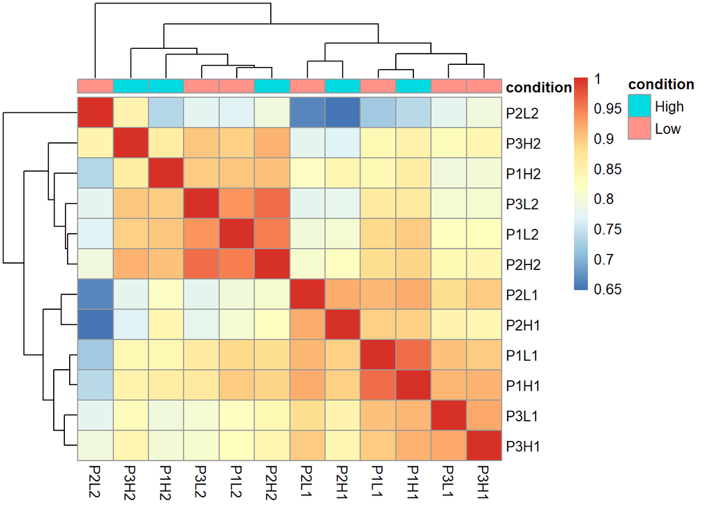

```r
#perform log transformation of the size factors to scale the gene expression levels more easily, save to the variable "vsd"
vsd <- vst(dds, blind = TRUE)

#extract vst matrix from the object, save to the variable "vsd_mat"
vsd_mat <- assay(vsd)
#get pairwise correlations of log2fold change in gene expression among all samples, save to the variable "vsd_cor"
vsd_cor <- cor(vsd_mat)
#plot the heatmap of these correlations to investigate patterns in gene expression among the samples in this study
pheatmap(vsd_cor, annotation = dplyr::select(metadata, condition))
```

```r
#there seem to be no visible patterns of clustering in gene expression between low and high acidity conditions. I will double check my results from the heatmap by visualizing the vsd variable in a PCA to see if there might be any patterns
```